# DATA624 - Project 2

Diego Correa & Lisa Szydziak

December 02, 2021

## Libraries

```r
library(kableExtra)
library(tidyverse)
library(ggplot2)
library(dplyr)
library(psych)
library(caret)
library(mice)
library(randomForest)
library(caTools)
library(corrplot)
library(class)
library(rpart)
library(AppliedPredictiveModeling)
library(naniar)
library(xgboost)
library(DiagrammeR)
library(readxl)
library(writexl)
library(DataExplorer)
library(elasticnet)
library(glmnet)
library(rattle)
```

## Background

### Problem Statement

This is role playing. I am your new boss. I am in charge of production at ABC Beverage and you are a team of data scientists reporting to me. My leadership has told me that new regulations are requiring us to understand our manufacturing process, the predictive factors and be able to report to them our predictive model of PH.

Please use the historical data set I am providing. Build and report the factors in **BOTH** a technical and non-technical report. I like to use Word and Excel. Please provide your non-technical report in a business friendly readable document and your predictions in an Excel readable format. The technical report should show clearly the models you tested and how you selected your final approach.

Please submit both Rpubs links and .rmd files or other readable formats for technical and non-technical reports. Also submit the excel file showing the prediction of your models for pH.

### Overview

To accomplish the goal of the assignment, these are the steps we will take.

1. Load
2. Transform
3. Explore
4. Model
5. Evaluate
6. Predict

## Dataset

```r
df <- read_xlsx('StudentData.xlsx')
head(df)%>% kable() %>% kable_styling(bootstrap_options = c("striped", "hover", "condensed", "responsive")) %>%
  scroll_box(width="100%",height="300px")
```

| Brand Code | Carb Volume | Fill Ounces | PC Volume | Carb Pressure | Carb Temp | PSC | PSC Fill | PSC CO2 | Mnf Flow | Carb Pressure1 | Fill Pressure | Hyd Pressure1 | Hyd Pressure2 | Hyd Pressure3 | Hyd Pressure4 | Filler Level | Filler Speed | Temperature | Usage cont | Carb Flow | Density | MFR | Balling | Pressure Vacuum | PH | Oxygen Filler | Bowl Setpoint | Pressure Setpoint | Air Pressurer | … |
| --- | --- | --- | --- | --- | --- | --- | --- | --- | --- | --- | --- | --- | --- | --- | --- | --- | --- | --- | --- | --- | --- | --- | --- | --- | --- | --- | --- | --- | --- | --- |
| B | 5.340000 | 23.96667 | 0.2633333 | 68.2 | 141.2 | 0.104 | 0.26 | 0.04 | -100 | 118.8 | 46.0 | 0 | NA | NA | 118 | 121.2 | 4002 | 66.0 | 16.18 | 2932 | 0.88 | 725.0 | 1.398 | -4.0 | 8.36 | 0.022 | 120 | 46.4 | 142.6 | … |
| A | 5.426667 | 24.00667 | 0.2386667 | 68.4 | 139.6 | 0.124 | 0.22 | 0.04 | -100 | 121.6 | 46.0 | 0 | NA | NA | 106 | 118.6 | 3986 | 67.6 | 19.90 | 3144 | 0.92 | 726.8 | 1.498 | -4.0 | 8.26 | 0.026 | 120 | 46.8 | 143.0 | … |
| B | 5.286667 | 24.06000 | 0.2633333 | 70.8 | 144.8 | 0.090 | 0.34 | 0.16 | -100 | 120.2 | 46.0 | 0 | NA | NA | 82 | 120.0 | 4020 | 67.0 | 17.76 | 2914 | 1.58 | 735.0 | 3.142 | -3.8 | 8.94 | 0.024 | 120 | 46.6 | 142.0 | … |
| A | 5.440000 | 24.00667 | 0.2933333 | 63.0 | 132.6 | NA | 0.42 | 0.04 | -100 | 115.2 | 46.4 | 0 | 0 | 0 | 92 | 117.8 | 4012 | 65.6 | 17.42 | 3062 | 1.54 | 730.6 | 3.042 | -4.4 | 8.24 | 0.030 | 120 | 46.0 | 146.2 | … |
| A | 5.486667 | 24.31333 | 0.1113333 | 67.2 | 136.8 | 0.026 | 0.16 | 0.12 | -100 | 118.4 | 45.8 | 0 | 0 | 0 | 92 | 118.6 | 4010 | 65.6 | 17.68 | 3054 | 1.54 | 722.8 | 3.042 | -4.4 | 8.26 | 0.030 | 120 | 46.0 | 146.2 | … |
| A | 5.380000 | 23.92667 | 0.2693333 | 66.6 | 138.4 | 0.090 | 0.24 | 0.04 | -100 | 119.6 | 45.6 | 0 | 0 | 0 | 116 | 120.2 | 4014 | 66.2 | 23.82 | 2948 | 1.52 | 738.8 | 2.992 | -4.4 | 8.32 | 0.024 | 120 | 46.0 | 146.6 | … |

### Descriptive Dataset Summary

```r
summary(df)%>% kable() %>% kable_styling(bootstrap_options = c("striped", "hover", "condensed", "responsive")) %>% scroll_box(width="100%",height="400px")
```

|  | Brand Code | Carb Volume | Fill Ounces | PC Volume | Carb Pressure | Carb Temp | PSC | PSC Fill | PSC CO2 | Mnf Flow | Carb Pressure1 | Fill Pressure | Hyd Pressure1 | Hyd Pressure2 | Hyd Pressure3 | Hyd Pressure4 | Filler Level | Filler Speed | Temperature | Usage cont | Carb Flow | Density | MFR | Balling | Pressure Vacuum | PH | Oxygen Filler | Bowl Setpoint | Pressure Setpoint | … |
| --- | --- | --- | --- | --- | --- | --- | --- | --- | --- | --- | --- | --- | --- | --- | --- | --- | --- | --- | --- | --- | --- | --- | --- | --- | --- | --- | --- | --- | --- | --- |
|  | Length:2571 | Min. :5.040 | Min. :23.63 | Min. :0.07933 | Min. :57.00 | Min. :128.6 | Min. :0.00200 | Min. :0.0000 | Min. :0.00000 | Min. :-100.20 | Min. :105.6 | Min. :34.60 | Min. :-0.80 | Min. : 0.00 | Min. :-1.20 | Min. : 52.00 | Min. : 55.8 | Min. : 998 | Min. :63.60 | Min. :12.08 | Min. : 26 | Min. :0.240 | Min. : 31.4 | Min. :-0.170 | Min. :-6.600 | Min. :7.880 | Min. :0.00240 | Min. : 70.0 | Min. :44.00 | … |
|  | Class :character | 1st Qu.:5.293 | 1st Qu.:23.92 | 1st Qu.:0.23917 | 1st Qu.:65.60 | 1st Qu.:138.4 | 1st Qu.:0.04800 | 1st Qu.:0.1000 | 1st Qu.:0.02000 | 1st Qu.:-100.00 | 1st Qu.:119.0 | 1st Qu.:46.00 | 1st Qu.: 0.00 | 1st Qu.: 0.00 | 1st Qu.: 0.00 | 1st Qu.: 86.00 | 1st Qu.: 98.3 | 1st Qu.:3888 | 1st Qu.:65.20 | 1st Qu.:18.36 | 1st Qu.:1144 | 1st Qu.:0.900 | 1st Qu.:706.3 | 1st Qu.: 1.496 | 1st Qu.:-5.600 | 1st Qu.:8.440 | 1st Qu.:0.02200 | 1st Qu.:100.0 | 1st Qu.:46.00 | … |
|  | Mode :character | Median :5.347 | Median :23.97 | Median :0.27133 | Median :68.20 | Median :140.8 | Median :0.07600 | Median :0.1800 | Median :0.04000 | Median : 65.20 | Median :123.2 | Median :46.40 | Median :11.40 | Median :28.60 | Median :27.60 | Median : 96.00 | Median :118.4 | Median :3982 | Median :65.60 | Median :21.79 | Median :3028 | Median :0.980 | Median :724.0 | Median : 1.648 | Median :-5.400 | Median :8.540 | Median :0.03340 | Median :120.0 | Median :46.00 | … |
|  | NA | Mean :5.370 | Mean :23.97 | Mean :0.27712 | Mean :68.19 | Mean :141.1 | Mean :0.08457 | Mean :0.1954 | Mean :0.05641 | Mean : 24.57 | Mean :122.6 | Mean :47.92 | Mean :12.44 | Mean :20.96 | Mean :20.46 | Mean : 96.29 | Mean :109.3 | Mean :3687 | Mean :65.97 | Mean :20.99 | Mean :2468 | Mean :1.174 | Mean :704.0 | Mean : 2.198 | Mean :-5.216 | Mean :8.546 | Mean :0.04684 | Mean :109.3 | Mean :47.62 | … |
|  | NA | 3rd Qu.:5.453 | 3rd Qu.:24.03 | 3rd Qu.:0.31200 | 3rd Qu.:70.60 | 3rd Qu.:143.8 | 3rd Qu.:0.11200 | 3rd Qu.:0.2600 | 3rd Qu.:0.08000 | 3rd Qu.: 140.80 | 3rd Qu.:125.4 | 3rd Qu.:50.00 | 3rd Qu.:20.20 | 3rd Qu.:34.60 | 3rd Qu.:33.40 | 3rd Qu.:102.00 | 3rd Qu.:120.0 | 3rd Qu.:3998 | 3rd Qu.:66.40 | 3rd Qu.:23.75 | 3rd Qu.:3186 | 3rd Qu.:1.620 | 3rd Qu.:731.0 | 3rd Qu.: 3.292 | 3rd Qu.:-5.000 | 3rd Qu.:8.680 | 3rd Qu.:0.06000 | 3rd Qu.:120.0 | 3rd Qu.:50.00 | … |
|  | NA | Max. :5.700 | Max. :24.32 | Max. :0.47800 | Max. :79.40 | Max. :154.0 | Max. :0.27000 | Max. :0.6200 | Max. :0.24000 | Max. : 229.40 | Max. :140.2 | Max. :60.40 | Max. :58.00 | Max. :59.40 | Max. :50.00 | Max. :142.00 | Max. :161.2 | Max. :4030 | Max. :76.20 | Max. :25.90 | Max. :5104 | Max. :1.920 | Max. :868.6 | Max. : 4.012 | Max. :-3.600 | Max. :9.360 | Max. :0.40000 | Max. :140.0 | Max. :52.00 | … |
|  | NA | NA’s :10 | NA’s :38 | NA’s :39 | NA’s :27 | NA’s :26 | NA’s :33 | NA’s :23 | NA’s :39 | NA’s :2 | NA’s :32 | NA’s :22 | NA’s :11 | NA’s :15 | NA’s :15 | NA’s :30 | NA’s :20 | NA’s :57 | NA’s :14 | NA’s :5 | NA’s :2 | NA’s :1 | NA’s :212 | NA’s :1 | NA | NA’s :4 | NA’s :12 | NA’s :2 | NA’s :12 | … |

## Pre-Processing

Before performing the imputation, we need to change the categorical variable into a factor and clean up white spaces from column names.

```r
# transforming the Brand Code variable into a factor for imputation
df <- df %>%
  mutate(`Brand Code` = as.factor(`Brand Code`))

# cleaning up the column names for the imputation function
colNamesNoSpace <- colnames(df) %>%
  str_remove_all(' ')

# transforming the column names
colnames(df) <- colNamesNoSpace
```

### Degenerate Variables

We also checked for presence of any de-generate variables. Here, we see that there is one degenerate variable, *HydPressure1*.

```r
# near zero variance
# capturing the degenerate variables
dim(df)
```

```
## [1] 2571   33
```

```r
nzv <- nearZeroVar(df)

# identifying them
(remove<-colnames(df)[nzv])
```

```
## [1] "HydPressure1"
```

```r
# removing from the dataset
df <- df[,!(colnames(df) == remove)]
dim(df)
```

```
## [1] 2571   32
```

### Missing Value Analysis

Based on the above descriptive data summary, there are quite a few variables with missing values. So we conducted an analysis of all missing values in various attributes to identify proper imputation technique.

```r
## Counts of missing data per feature
dataset_missing_counts <- data.frame(apply(df, 2, function(x) length(which(is.na(x)))))
dataset_missing_pct <- data.frame(apply(df, 2,function(x) {sum(is.na(x)) / length(x) * 100}))

dataset_missing_counts <- cbind(Feature = rownames(dataset_missing_counts), dataset_missing_counts, dataset_missing_pct)
colnames(dataset_missing_counts) <- c('Feature','NA_Count','NA_Percentage')
rownames(dataset_missing_counts) <- NULL

dataset_missing_counts <- dataset_missing_counts %>% filter(`NA_Count` != 0) %>% arrange(desc(`NA_Count`))

dataset_missing_counts  %>% kable() %>% kable_styling(bootstrap_options = c("striped", "hover", "condensed", "responsive")) %>% scroll_box(width="100%",height="300px")
```

| Feature | NA_Count | NA_Percentage |
| --- | --- | --- |
| MFR | 212 | 8.2458187 |
| BrandCode | 120 | 4.6674446 |
| FillerSpeed | 57 | 2.2170362 |
| PCVolume | 39 | 1.5169195 |
| PSCCO2 | 39 | 1.5169195 |
| FillOunces | 38 | 1.4780241 |
| PSC | 33 | 1.2835473 |
| CarbPressure1 | 32 | 1.2446519 |
| HydPressure4 | 30 | 1.1668611 |
| CarbPressure | 27 | 1.0501750 |
| CarbTemp | 26 | 1.0112797 |
| PSCFill | 23 | 0.8945935 |
| FillPressure | 22 | 0.8556982 |
| FillerLevel | 20 | 0.7779074 |
| HydPressure2 | 15 | 0.5834306 |
| HydPressure3 | 15 | 0.5834306 |
| Temperature | 14 | 0.5445352 |
| OxygenFiller | 12 | 0.4667445 |
| PressureSetpoint | 12 | 0.4667445 |
| CarbVolume | 10 | 0.3889537 |
| CarbRel | 10 | 0.3889537 |
| AlchRel | 9 | 0.3500583 |
| Usagecont | 5 | 0.1944769 |
| PH | 4 | 0.1555815 |
| MnfFlow | 2 | 0.0777907 |
| CarbFlow | 2 | 0.0777907 |
| BowlSetpoint | 2 | 0.0777907 |
| Density | 1 | 0.0388954 |
| Balling | 1 | 0.0388954 |
| BallingLvl | 1 | 0.0388954 |

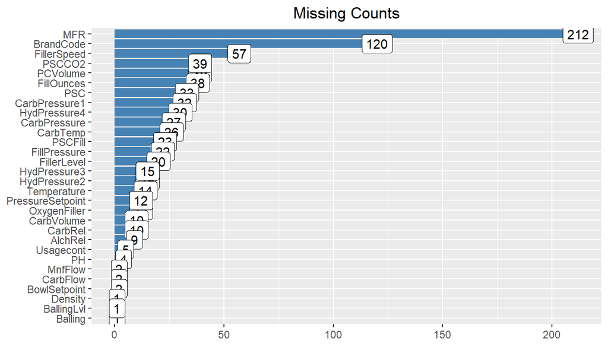

```r
ggplot(dataset_missing_counts, aes(x = NA_Count, y = reorder(Feature, NA_Count))) +
  geom_bar(stat = 'identity', fill = 'steelblue') +
  geom_label(aes(label = NA_Count)) +
  labs(title = 'Missing Counts') +
  theme(plot.title = element_text(hjust = 0.5), axis.title.y = element_blank(), axis.title.x = element_blank())
```

### Removing Rows with Missing Brand Code

To avoid risk of imputing the incorrect Brand Code, we remove the **NA** rows, a total 120 rows.

```r
#remove missing brand => df3
df <- df[!is.na(df$BrandCode), ]
dim(df)
```

```
## [1] 2451   32
```

### Finding Highly Correlated Variables

```r
# remove highly correlated variables
corrMatrix <- round(cor(df[,-1]),4)

highCorr <- findCorrelation(corrMatrix,
  cutoff = 0.9,
  verbose = FALSE,
  names = TRUE,
  exact = TRUE)

# identify
highCorr %>%
  kable() %>% kable_styling(bootstrap_options = c("striped", "hover", "condensed", "responsive")) %>% scroll_box(width="100%",height="200px")
```

| x |
| --- |

### Data Imputation

Once done, we can perform the imputation using the *random forest* method of the *mice* package

```r
#imputation by using the random forest method ('rf')
init <- mice(df, maxit = 0)
predM <- init$predictorMatrix
set.seed(123)
imputed <- mice(df, method = 'rf', predictorMatrix = predM, m=1, silent = TRUE)
df <- complete(imputed, silent = TRUE)
summary(df)
```

```
##  BrandCode   CarbVolume      FillOunces       PCVolume        CarbPressure
##  A: 293    Min.   :5.040   Min.   :23.63   Min.   :0.08667   Min.   :57.00
##  B:1239    1st Qu.:5.293   1st Qu.:23.92   1st Qu.:0.23933   1st Qu.:65.80
##  C: 304    Median :5.347   Median :23.97   Median :0.27133   Median :68.20
##  D: 615    Mean   :5.374   Mean   :23.97   Mean   :0.27700   Mean   :68.31
##            3rd Qu.:5.460   3rd Qu.:24.03   3rd Qu.:0.31133   3rd Qu.:70.60
##            Max.   :5.700   Max.   :24.32   Max.   :0.47067   Max.   :79.40
##     CarbTemp          PSC             PSCFill           PSCCO2
##  Min.   :128.6   Min.   :0.00200   Min.   :0.0000   Min.   :0.00000
##  1st Qu.:138.4   1st Qu.:0.04800   1st Qu.:0.1000   1st Qu.:0.02000
##  Median :140.8   Median :0.07800   Median :0.1800   Median :0.04000
##  Mean   :141.2   Mean   :0.08462   Mean   :0.1958   Mean   :0.05672
##  3rd Qu.:143.8   3rd Qu.:0.11200   3rd Qu.:0.2600   3rd Qu.:0.08000
##  Max.   :154.0   Max.   :0.27000   Max.   :0.6200   Max.   :0.24000
##     MnfFlow        CarbPressure1    FillPressure    HydPressure2
##  Min.   :-100.20   Min.   :105.6   Min.   :34.60   Min.   : 0.00
##  1st Qu.:-100.00   1st Qu.:118.8   1st Qu.:46.00   1st Qu.: 0.00
##  Median :  65.20   Median :123.2   Median :46.40   Median :28.60
##  Mean   :  24.42   Mean   :122.5   Mean   :47.86   Mean   :21.03
##  3rd Qu.: 141.20   3rd Qu.:125.4   3rd Qu.:50.00   3rd Qu.:34.80
##  Max.   : 216.20   Max.   :140.2   Max.   :60.40   Max.   :59.40
##   HydPressure3    HydPressure4     FillerLevel     FillerSpeed
##  Min.   :-1.20   Min.   : 52.00   Min.   : 55.8   Min.   : 998
##  1st Qu.: 0.00   1st Qu.: 88.00   1st Qu.: 97.3   1st Qu.:3867
##  Median :27.40   Median : 96.00   Median :118.2   Median :3982
##  Mean   :20.41   Mean   : 96.55   Mean   :109.1   Mean   :3645
##  3rd Qu.:33.20   3rd Qu.:102.00   3rd Qu.:120.0   3rd Qu.:3998
##  Max.   :50.00   Max.   :142.00   Max.   :161.2   Max.   :4030
##   Temperature      Usagecont        CarbFlow       Density           MFR
##  Min.   :63.60   Min.   :12.08   Min.   :  26   Min.   :0.240   Min.   : 31.4
##  1st Qu.:65.20   1st Qu.:18.39   1st Qu.:1125   1st Qu.:0.900   1st Qu.:697.2
##  Median :65.60   Median :21.80   Median :3028   Median :0.980   Median :722.2
##  Mean   :65.93   Mean   :21.00   Mean   :2464   Mean   :1.184   Mean   :675.2
##  3rd Qu.:66.40   3rd Qu.:23.76   3rd Qu.:3184   3rd Qu.:1.640   3rd Qu.:730.6
##  Max.   :76.20   Max.   :25.90   Max.   :5104   Max.   :1.920   Max.   :868.6
##     Balling       PressureVacuum        PH         OxygenFiller
##  Min.   :-0.170   Min.   :-6.60   Min.   :7.880   Min.   :0.00240
##  1st Qu.: 1.496   1st Qu.:-5.60   1st Qu.:8.440   1st Qu.:0.02200
##  Median : 1.648   Median :-5.40   Median :8.540   Median :0.03340
##  Mean   : 2.224   Mean   :-5.21   Mean   :8.548   Mean   :0.04701
##  3rd Qu.: 3.340   3rd Qu.:-5.00   3rd Qu.:8.680   3rd Qu.:0.06000
##  Max.   : 4.012   Max.   :-3.60   Max.   :9.360   Max.   :0.40000
##   BowlSetpoint   PressureSetpoint  AirPressurer      AlchRel
##  Min.   : 70.0   Min.   :44.0     Min.   :140.8   Min.   :6.240
##  1st Qu.:100.0   1st Qu.:46.0     1st Qu.:142.2   1st Qu.:6.540
##  Median :120.0   Median :46.0     Median :142.6   Median :6.580
##  Mean   :109.2   Mean   :47.6     Mean   :142.8   Mean   :6.909
##  3rd Qu.:120.0   3rd Qu.:50.0     3rd Qu.:143.0   3rd Qu.:7.620
##  Max.   :140.0   Max.   :52.0     Max.   :148.2   Max.   :8.560
##     CarbRel        BallingLvl
##  Min.   :4.960   Min.   :0.000
##  1st Qu.:5.340   1st Qu.:1.380
##  Median :5.400   Median :1.480
##  Mean   :5.441   Mean   :2.078
##  3rd Qu.:5.560   3rd Qu.:3.160
##  Max.   :6.060   Max.   :3.660
```

## Exploratory Analysis

### Distribution

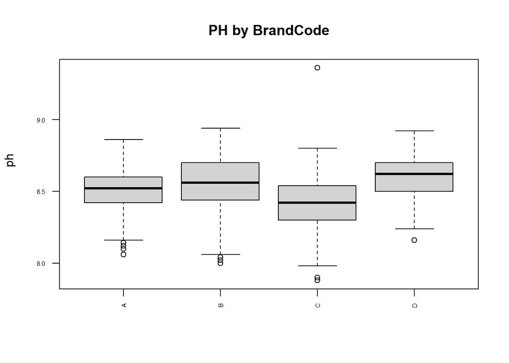

```r
# Categorical
boxplot(df$PH ~df$BrandCode, main="PH by BrandCode", ylab="
        ph", cex.axis=.5, xlab="",las=2)
```

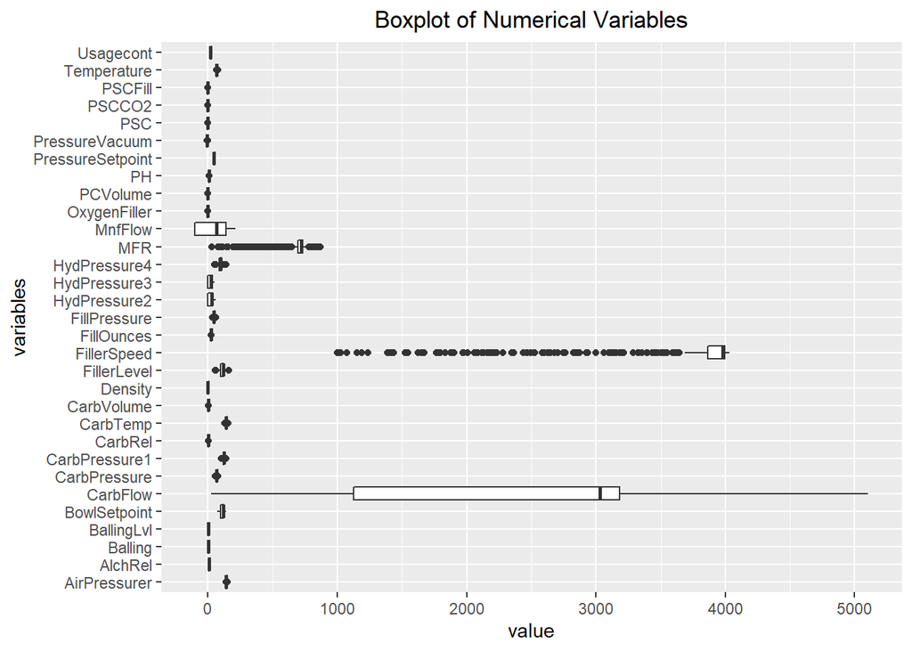

```r
# numerical
# make dataset long to place data in boxplots
vars <- df %>%
  select(-BrandCode) %>%
  gather(key = 'variables', value = 'value')

# boxplot
vars %>%
  ggplot(aes(x = variables, y = value)) +
  geom_boxplot() +
  labs(title = 'Boxplot of Numerical Variables') +
  theme(plot.title = element_text(hjust = 0.5)) +
  coord_flip()
```

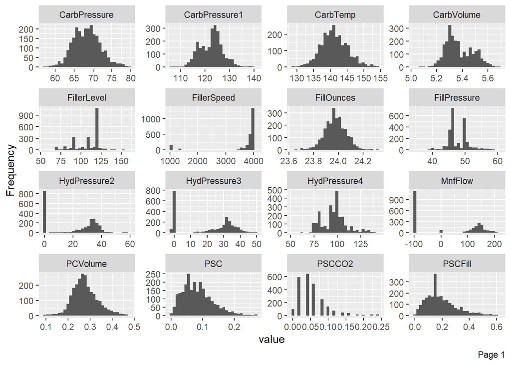

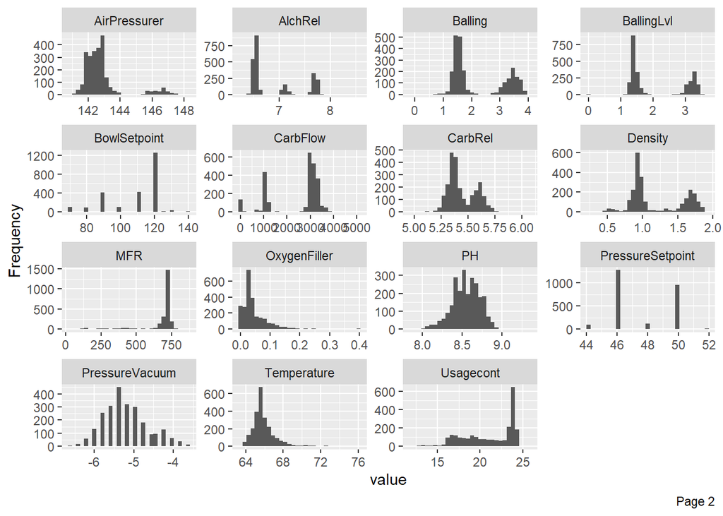

```r
# histogram of variables
DataExplorer::plot_histogram(df)
```

From the histograms above, we can classify the variables into the distribution categories:

- **Symmetric**: CarbPressure, CarbPress, CarbTamp, FillOunces, PCVolume, PressureVacuum
- **Left-skewed**: FillerLevel, Fillerspeed, MFR, Usagecont
- **Right-skewed**: PSC, PSCCO2, PSCFill, OxygenFiller, Temperaturet
- **Multi-modal**: CarbVolume, FillPressure, HydPressure2, HydPressure3, HydPRessure4, MnfFlow, AirPressure, AlchRel, Balling, BallingLvl, BowlSetpoint, Carbflow, CarbRel, Density, PressureSetpoint

Unfortunately, we were not provided a data dictionary or access to an advisor. We noted that HydPressure2 and HydPressure3 have a large proportion of 0 values. Is this feasible or could these be missing values? Could the multimodal distributed values represent discrete machine settings and maybe better represented as a categorical or ordinal variable? Without a data dictionary or expert advice, we will assume the variables are continuous variables.

### Correlation Plot: Multicollinearity Check

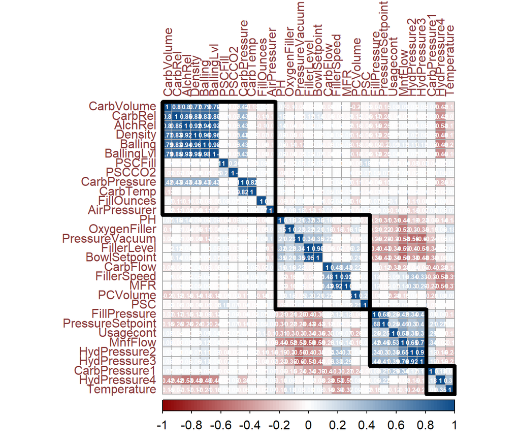

```r
corrMatrix <- round(cor(df[,-1]),4)

corrMatrix %>% corrplot(., method = "color", outline = T, addgrid.col = "darkgray", order="hclust", addrect = 4, rect.col = "black", rect.lwd = 5,cl.pos = "b", tl.col = "indianred4", tl.cex = 1.0, cl.cex = 1.0, addCoef.col = "white", number.digits = 2, number.cex = 0.5, col = colorRampPalette(c("darkred","white","dodgerblue4"))(100))
```

## Model Building

### Overview

We will first split the training and test data into a 75/25 split. We will then create a dummy variable for the factor variable, **Brand Code**, in order to utilize all models. Next, the independent and dependent will be identified as X and y, respectively.

Once this is done we can, we will perform 2 models of each regression family type: **Linear**, **Non Linear**, **Tree and Rules**.

We will take a look at the variable importance of each model and capture the performance on the hold out dataset.

Lastly, we will take the model with the highest **Rsquared** as our best model and perform a prediction on the evaluation dataset.

### Splitting Data: Train/Test

```r
set.seed(123)
sample <- sample.split(df$PH, SplitRatio = 0.75)
train <- subset(df, sample == TRUE)
train <- model.matrix( ~ .-1, train)

test <- subset(df, sample == FALSE)
test <- model.matrix( ~ .-1, test)

y_train <- train[,'PH']
y_test <- test[,'PH']

X_train <- train[, !(colnames(train) == 'PH')]
X_test <- test[, !(colnames(test) == 'PH')]
```

### Linear Regression

#### Ordinary Least Square

```r
lmFit <- train(X_train, y_train,
                  method = 'lm',
                  preProc = c('center','scale'),
                  trControl = trainControl(method = 'cv')
                  )
lmFit
```

```
## Linear Regression
##
## 1838 samples
##   34 predictor
##
## Pre-processing: centered (34), scaled (34)
## Resampling: Cross-Validated (10 fold)
## Summary of sample sizes: 1654, 1653, 1655, 1654, 1653, 1655, ...
## Resampling results:
##
##   RMSE       Rsquared   MAE
##   0.1357171  0.3845636  0.1054333
##
## Tuning parameter 'intercept' was held constant at a value of TRUE
```

##### Residual Analysis

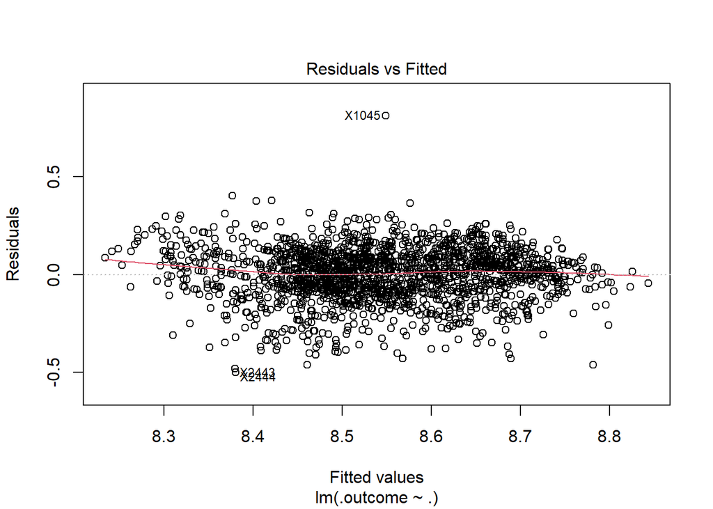

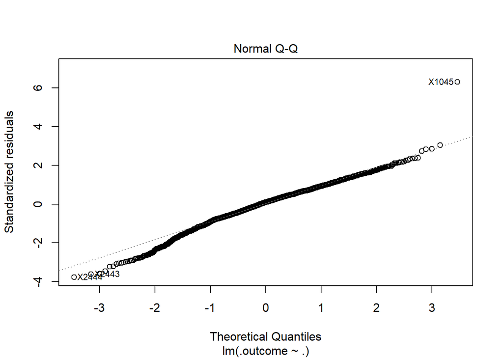

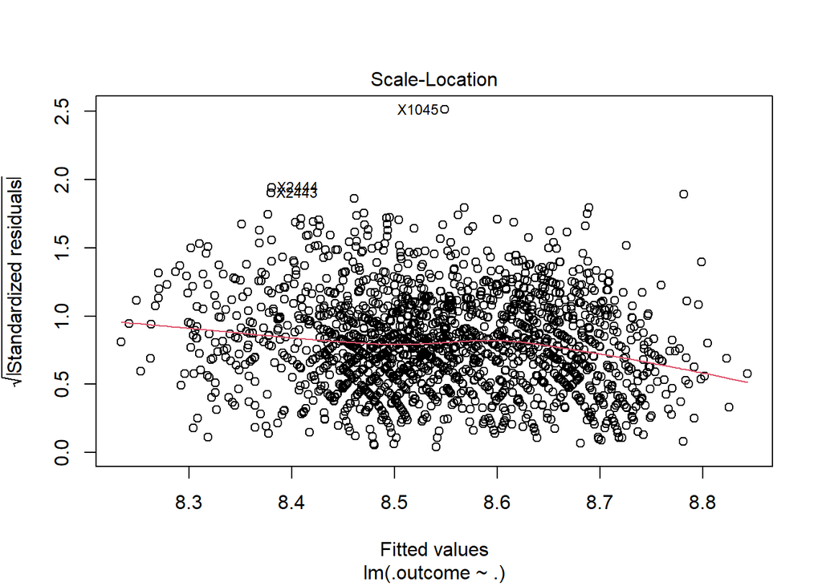

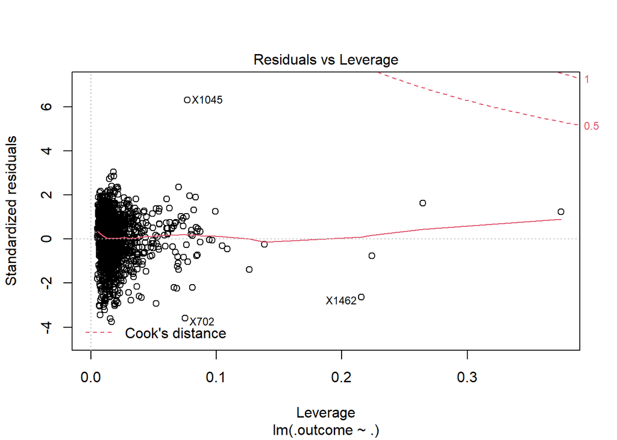

```r
plot(lmFit$finalModel)
```

The diagnostic plots reveal some concern over the Residuals vs Fitted. This plot should exhibit no patterns. The QQ plot should follow a straight line and there is a departure on the left side. The scale-location plot line is not straight and drifts downward. The Leverage plot does exhibit concerning points as well.

##### Variable Importance

```r
varimp <- varImp(lmFit)

varimp$importance %>%
  arrange(desc(Overall)) %>%
  kable() %>% kable_styling(bootstrap_options = c("striped", "hover", "condensed", "responsive")) %>% scroll_box(width="100%",height="400px")
```

|  | Overall |
| --- | --- |
| MnfFlow | 100.000000 |
| CarbPressure1 | 63.187685 |
| HydPressure3 | 37.111454 |
| Temperature | 33.655251 |
| Usagecont | 33.368963 |
| BowlSetpoint | 32.223744 |
| Density | 26.203536 |
| PressureSetpoint | 24.150945 |
| OxygenFiller | 23.749691 |
| BrandCodeC | 22.693949 |
| BallingLvl | 22.323489 |
| AlchRel | 18.562396 |
| FillOunces | 17.860508 |
| PCVolume | 16.130986 |
| Balling | 15.321388 |
| PSCFill | 15.231630 |
| CarbFlow | 13.889807 |
| MFR | 13.778058 |
| BrandCodeA | 13.040450 |
| PSCCO2 | 12.482412 |
| HydPressure2 | 10.766061 |
| FillerSpeed | 10.705281 |
| FillerLevel | 8.989604 |
| AirPressurer | 8.336756 |
| PressureVacuum | 7.811428 |
| FillPressure | 7.257734 |
| CarbRel | 4.738633 |
| BrandCodeB | 4.702300 |
| CarbVolume | 4.296034 |
| PSC | 3.768463 |
| HydPressure4 | 1.009254 |
| CarbTemp | 0.771186 |
| CarbPressure | 0.000000 |

##### Prediction Performance

```r
lm_Pred <- predict(lmFit, newdata = X_test)
lmPredPerf <- postResample(pred = lm_Pred, obs = y_test)

lmPredPerf['Family'] <- 'Linear'

# saving model prediction performance
modelPredPerf <- data.frame(rbind(lm = lmPredPerf))
```

#### Elastic Net

```r
enetGrid <- expand.grid(.lambda = c(0,0.01,0.1),
            .fraction = seq(0.05,1,length = 20))

set.seed(213)
enetTune <- train(X_train, y_train,
                  method = 'enet',
                  preProc = c('center','scale'),
                  tuneGrid = enetGrid,
                  trControl = trainControl(method = 'cv')
                  )
enetTune
```

```
## Elasticnet
##
## 1838 samples
##   34 predictor
##
## Pre-processing: centered (34), scaled (34)
## Resampling: Cross-Validated (10 fold)
## Summary of sample sizes: 1655, 1653, 1655, 1653, 1653, 1655, ...
## Resampling results across tuning parameters:
##
##   lambda  fraction  RMSE       Rsquared   MAE
##   0.00    0.05      0.1594181  0.2421211  0.1274611
##   0.00    0.10      0.1508963  0.2870210  0.1201409
##   0.00    0.15      0.1461062  0.3085183  0.1160208
##   0.00    0.20      0.1428295  0.3304116  0.1131066
##   0.00    0.25      0.1403685  0.3481322  0.1109448
##   0.00    0.30      0.1385503  0.3620985  0.1092429
##   0.00    0.35      0.1374238  0.3701068  0.1080466
##   0.00    0.40      0.1366838  0.3751849  0.1071298
##   0.00    0.45      0.1362466  0.3783356  0.1065466
##   0.00    0.50      0.1358365  0.3816027  0.1060263
##   0.00    0.55      0.1355623  0.3838794  0.1056378
##   0.00    0.60      0.1353530  0.3858426  0.1053413
##   0.00    0.65      0.1352604  0.3867479  0.1051351
##   0.00    0.70      0.1352622  0.3868130  0.1050523
##   0.00    0.75      0.1352964  0.3866307  0.1050440
##   0.00    0.80      0.1352858  0.3869250  0.1050263
##   0.00    0.85      0.1352691  0.3872454  0.1049957
##   0.00    0.90      0.1352811  0.3873364  0.1049717
##   0.00    0.95      0.1353159  0.3872630  0.1049626
##   0.00    1.00      0.1353448  0.3872084  0.1049774
##   0.01    0.05      0.1617693  0.2206851  0.1295299
##   0.01    0.10      0.1540843  0.2740077  0.1228096
##   0.01    0.15      0.1488478  0.2921870  0.1183467
##   0.01    0.20      0.1453349  0.3139255  0.1153309
##   0.01    0.25      0.1427644  0.3325691  0.1131085
##   0.01    0.30      0.1408343  0.3459918  0.1114360
##   0.01    0.35      0.1392048  0.3588129  0.1099309
##   0.01    0.40      0.1380570  0.3666159  0.1087011
##   0.01    0.45      0.1372182  0.3723264  0.1077154
```

[output cut: 19 more lines]

```
##   0.10    0.45      0.1400476  0.3486849  0.1106672
##   0.10    0.50      0.1390805  0.3561940  0.1096901
##   0.10    0.55      0.1383856  0.3612655  0.1089433
##   0.10    0.60      0.1378768  0.3649947  0.1083449
##   0.10    0.65      0.1375146  0.3678612  0.1078842
##   0.10    0.70      0.1371749  0.3706499  0.1074605
##   0.10    0.75      0.1368877  0.3730726  0.1070972
##   0.10    0.80      0.1366540  0.3751016  0.1067685
##   0.10    0.85      0.1364312  0.3770946  0.1064839
##   0.10    0.90      0.1362413  0.3788108  0.1062394
##   0.10    0.95      0.1361149  0.3800147  0.1060677
##   0.10    1.00      0.1360143  0.3810034  0.1059430
##
## RMSE was used to select the optimal model using the smallest value.
## The final values used for the model were fraction = 1 and lambda = 0.01.
```

##### Variable Importance

```r
varimp <- varImp(enetTune)

varimp$importance %>%
  arrange(desc(Overall)) %>%
  kable() %>% kable_styling(bootstrap_options = c("striped", "hover", "condensed", "responsive")) %>% scroll_box(width="100%",height="400px")
```

|  | Overall |
| --- | --- |
| MnfFlow | 100.0000000 |
| Usagecont | 69.2766428 |
| BowlSetpoint | 57.2437485 |
| FillerLevel | 50.8583228 |
| PressureSetpoint | 44.1772076 |
| BrandCodeC | 43.7880379 |
| CarbFlow | 38.2422547 |
| HydPressure3 | 24.7297152 |
| PressureVacuum | 23.3682750 |
| FillPressure | 21.8618080 |
| HydPressure2 | 16.2828184 |
| BrandCodeD | 14.1425615 |
| OxygenFiller | 10.5003903 |
| CarbRel | 10.2468468 |
| Temperature | 9.0620329 |
| HydPressure4 | 8.8632613 |
| AlchRel | 8.5201559 |
| BrandCodeB | 7.4073347 |
| BrandCodeA | 5.1468240 |
| FillOunces | 4.9357578 |
| PSC | 4.1257338 |
| PSCCO2 | 3.3972054 |
| PCVolume | 3.2846205 |
| BallingLvl | 3.0449649 |
| Density | 1.9110063 |
| PSCFill | 1.8130365 |
| MFR | 1.7614789 |
| CarbVolume | 1.4719802 |
| CarbPressure1 | 1.1273341 |
| Balling | 1.0176082 |
| CarbPressure | 0.8775290 |
| FillerSpeed | 0.1823979 |
| CarbTemp | 0.0117359 |
| AirPressurer | 0.0000000 |

##### Prediction Performance

```r
enetPred <- predict(enetTune, newdata = X_test)
enetPredPerf <- postResample(pred = enetPred, obs = y_test)

enetPredPerf['Family'] <- 'Linear'

# saving model prediction performance
modelPredPerf <- rbind(modelPredPerf,elastic_net = enetPredPerf)
```

### Non Linear Regression

#### Support Vector Machine

```r
svmRTuned <- train(X_train, y_train,
                 method = 'svmRadial',
                 preProc = c('center','scale'),
                 tuneLength = 14,
                 trControl = trainControl(method = 'cv'))

svmRTuned
```

```
## Support Vector Machines with Radial Basis Function Kernel
##
## 1838 samples
##   34 predictor
##
## Pre-processing: centered (34), scaled (34)
## Resampling: Cross-Validated (10 fold)
## Summary of sample sizes: 1655, 1656, 1654, 1653, 1655, 1654, ...
## Resampling results across tuning parameters:
##
##   C        RMSE       Rsquared   MAE
##      0.25  0.1266445  0.4721916  0.09401414
##      0.50  0.1235081  0.4946179  0.09092216
##      1.00  0.1209978  0.5132580  0.08870062
##      2.00  0.1193126  0.5265046  0.08750538
##      4.00  0.1175024  0.5404473  0.08635614
##      8.00  0.1169993  0.5460900  0.08652649
##     16.00  0.1178836  0.5447947  0.08737787
##     32.00  0.1227274  0.5212937  0.09032960
##     64.00  0.1289240  0.4939767  0.09483409
##    128.00  0.1373354  0.4579998  0.10110100
##    256.00  0.1446848  0.4306996  0.10672403
##    512.00  0.1513160  0.4079947  0.11171768
##   1024.00  0.1543055  0.3957866  0.11399901
##   2048.00  0.1543055  0.3957866  0.11399901
##
## Tuning parameter 'sigma' was held constant at a value of 0.0206858
## RMSE was used to select the optimal model using the smallest value.
## The final values used for the model were sigma = 0.0206858 and C = 8.
```

##### Variable Importance

```r
varimp <- varImp(svmRTuned)

varimp$importance %>%
  arrange(desc(Overall)) %>%
  kable() %>% kable_styling(bootstrap_options = c("striped", "hover", "condensed", "responsive")) %>% scroll_box(width="100%",height="400px")
```

|  | Overall |
| --- | --- |
| MnfFlow | 100.0000000 |
| Usagecont | 69.2766428 |
| BowlSetpoint | 57.2437485 |
| FillerLevel | 50.8583228 |
| PressureSetpoint | 44.1772076 |
| BrandCodeC | 43.7880379 |
| CarbFlow | 38.2422547 |
| HydPressure3 | 24.7297152 |
| PressureVacuum | 23.3682750 |
| FillPressure | 21.8618080 |
| HydPressure2 | 16.2828184 |
| BrandCodeD | 14.1425615 |
| OxygenFiller | 10.5003903 |
| CarbRel | 10.2468468 |
| Temperature | 9.0620329 |
| HydPressure4 | 8.8632613 |
| AlchRel | 8.5201559 |
| BrandCodeB | 7.4073347 |
| BrandCodeA | 5.1468240 |
| FillOunces | 4.9357578 |
| PSC | 4.1257338 |
| PSCCO2 | 3.3972054 |
| PCVolume | 3.2846205 |
| BallingLvl | 3.0449649 |
| Density | 1.9110063 |
| PSCFill | 1.8130365 |
| MFR | 1.7614789 |
| CarbVolume | 1.4719802 |
| CarbPressure1 | 1.1273341 |
| Balling | 1.0176082 |
| CarbPressure | 0.8775290 |
| FillerSpeed | 0.1823979 |
| CarbTemp | 0.0117359 |
| AirPressurer | 0.0000000 |

##### Prediction Performace

```r
svmRPred <- predict(svmRTuned, newdata = X_test)
svmRPredPerf <- postResample(pred = svmRPred, obs = y_test)

svmRPredPerf['Family'] <- 'NonLinear'

# saving model prediction performance
modelPredPerf <- rbind(modelPredPerf,svm_radial = svmRPredPerf)
```

#### Neural Network

```r
# neural network
nnetGrid <- expand.grid(.decay = c(0,0.01,.1),
                        .size = c(1:5),
                        .bag = FALSE)

nnetFit <- train(X_train, y_train,
                  method = 'avNNet',
                  preProc = c('center','scale'),
                  tuneGrid = nnetGrid,
                  linout = TRUE,
                  trace = FALSE,
                  MaxNWts = 5 * (ncol(X_train) + 1 + 5 + 1),
                  maxit = 100

)
nnetFit
```

```
## Model Averaged Neural Network
##
## 1838 samples
##   34 predictor
##
## Pre-processing: centered (34), scaled (34)
## Resampling: Bootstrapped (25 reps)
## Summary of sample sizes: 1838, 1838, 1838, 1838, 1838, 1838, ...
## Resampling results across tuning parameters:
##
##   decay  size  RMSE       Rsquared   MAE
##   0.00   1     0.1933439  0.1864359  0.12151840
##   0.00   2     0.2671241  0.1522010  0.12375482
##   0.00   3     0.2131091  0.2824768  0.10771429
##   0.00   4     0.1293532  0.4502129  0.09580797
##   0.00   5     0.1259340  0.4777182  0.09317359
##   0.01   1     0.1460670  0.3232886  0.10856975
##   0.01   2     0.1777732  0.2308782  0.11101188
##   0.01   3     0.1472257  0.3812926  0.09961886
##   0.01   4     0.1249013  0.4837255  0.09376834
##   0.01   5     0.1256862  0.4831068  0.09328069
##   0.10   1     0.1372620  0.3807262  0.10511896
##   0.10   2     0.1468081  0.3107366  0.10982136
##   0.10   3     0.1548665  0.3495874  0.10316415
##   0.10   4     0.1260535  0.4745737  0.09553511
##   0.10   5     0.1248377  0.4848205  0.09441037
##
## Tuning parameter 'bag' was held constant at a value of FALSE
## RMSE was used to select the optimal model using the smallest value.
## The final values used for the model were size = 5, decay = 0.1 and bag = FALSE.
```

##### Variable Importance

```r
varimp <- varImp(nnetFit)

varimp$importance %>%
  arrange(desc(Overall)) %>%
  kable() %>% kable_styling(bootstrap_options = c("striped", "hover", "condensed", "responsive")) %>% scroll_box(width="100%",height="400px")
```

|  | Overall |
| --- | --- |
| MnfFlow | 100.0000000 |
| Usagecont | 69.2766428 |
| BowlSetpoint | 57.2437485 |
| FillerLevel | 50.8583228 |
| PressureSetpoint | 44.1772076 |
| BrandCodeC | 43.7880379 |
| CarbFlow | 38.2422547 |
| HydPressure3 | 24.7297152 |
| PressureVacuum | 23.3682750 |
| FillPressure | 21.8618080 |
| HydPressure2 | 16.2828184 |
| BrandCodeD | 14.1425615 |
| OxygenFiller | 10.5003903 |
| CarbRel | 10.2468468 |
| Temperature | 9.0620329 |
| HydPressure4 | 8.8632613 |
| AlchRel | 8.5201559 |
| BrandCodeB | 7.4073347 |
| BrandCodeA | 5.1468240 |
| FillOunces | 4.9357578 |
| PSC | 4.1257338 |
| PSCCO2 | 3.3972054 |
| PCVolume | 3.2846205 |
| BallingLvl | 3.0449649 |
| Density | 1.9110063 |
| PSCFill | 1.8130365 |
| MFR | 1.7614789 |
| CarbVolume | 1.4719802 |
| CarbPressure1 | 1.1273341 |
| Balling | 1.0176082 |
| CarbPressure | 0.8775290 |
| FillerSpeed | 0.1823979 |
| CarbTemp | 0.0117359 |
| AirPressurer | 0.0000000 |

##### Prediction Performance

```r
nnetPred <- predict(nnetFit, newdata = X_test)
nnetPredPerf <- postResample(pred = nnetPred, obs = y_test)

nnetPredPerf['Family'] <- 'NonLinear'

# saving model prediction performance
modelPredPerf <- rbind(modelPredPerf,neural_net = nnetPredPerf)
```

### Trees and Rules

#### Random Forest

```r
rfmodel <- train(X_train, y_train,
                 method = 'rf',
                 preProc = c('center','scale'),
                 trControl = trainControl(method = 'cv'))

rfmodel
```

```
## Random Forest
##
## 1838 samples
##   34 predictor
##
## Pre-processing: centered (34), scaled (34)
## Resampling: Cross-Validated (10 fold)
## Summary of sample sizes: 1654, 1654, 1653, 1653, 1656, 1654, ...
## Resampling results across tuning parameters:
##
##   mtry  RMSE       Rsquared   MAE
##    2    0.1143616  0.6080012  0.08631204
##   18    0.1006756  0.6729194  0.07251130
##   34    0.1000516  0.6701545  0.07167922
##
## RMSE was used to select the optimal model using the smallest value.
## The final value used for the model was mtry = 34.
```

##### Variable Importance

```r
varimp <- varImp(rfmodel)

varimp$importance %>%
  arrange(desc(Overall)) %>%
  kable() %>% kable_styling(bootstrap_options = c("striped", "hover", "condensed", "responsive")) %>% scroll_box(width="100%",height="400px")
```

|  | Overall |
| --- | --- |
| MnfFlow | 100.0000000 |
| BrandCodeC | 32.9791581 |
| OxygenFiller | 25.1211507 |
| AlchRel | 23.0500172 |
| AirPressurer | 21.4981865 |
| PressureVacuum | 18.4859680 |
| BallingLvl | 17.4312097 |
| CarbRel | 15.7352773 |
| CarbPressure1 | 13.8219323 |
| Temperature | 12.2853810 |
| Usagecont | 12.0620345 |
| CarbFlow | 11.8643196 |
| HydPressure3 | 10.4302866 |
| FillerSpeed | 10.1567336 |
| Density | 8.6051131 |
| Balling | 8.2544745 |
| FillerLevel | 7.3460338 |
| PCVolume | 7.2139284 |
| FillOunces | 6.7377716 |
| CarbVolume | 6.6267703 |
| FillPressure | 6.6175996 |
| MFR | 6.5439064 |
| HydPressure2 | 5.7663144 |
| BowlSetpoint | 5.2854966 |
| PSC | 5.2668915 |
| PSCFill | 4.2538893 |
| HydPressure4 | 4.0522002 |
| CarbPressure | 3.6348795 |
| CarbTemp | 3.1968389 |
| PSCCO2 | 2.9732825 |
| PressureSetpoint | 1.5325994 |
| BrandCodeA | 1.5117571 |
| BrandCodeB | 0.4281065 |
| BrandCodeD | 0.0000000 |

##### Prediction Performance

```r
rfPred <- predict(rfmodel, newdata = X_test)
rfPredPerf <- postResample(pred = rfPred, obs = y_test)


rfPredPerf['Family'] <- 'TreesAndRules'

# saving model prediction performance
modelPredPerf <- rbind(modelPredPerf, rf = rfPredPerf)
```

#### Cubist

```r
set.seed(123)

cubist_Model <- train(x = X_train, y = y_train,
                      method = "cubist",
                      preProc = c('center','scale'),
                      trControl = trainControl(method = 'cv'))

cubist_Model
```

```
## Cubist
##
## 1838 samples
##   34 predictor
##
## Pre-processing: centered (34), scaled (34)
## Resampling: Cross-Validated (10 fold)
## Summary of sample sizes: 1653, 1654, 1654, 1655, 1654, 1656, ...
## Resampling results across tuning parameters:
##
##   committees  neighbors  RMSE       Rsquared   MAE
##    1          0          0.1213716  0.5316270  0.08440854
##    1          5          0.1191605  0.5595143  0.08131312
##    1          9          0.1184966  0.5587677  0.08104720
##   10          0          0.1050136  0.6347628  0.07697248
##   10          5          0.1023614  0.6521372  0.07278536
##   10          9          0.1015647  0.6558187  0.07273128
##   20          0          0.1043489  0.6413283  0.07604857
##   20          5          0.1013335  0.6583605  0.07176922
##   20          9          0.1006968  0.6613563  0.07180303
##
## RMSE was used to select the optimal model using the smallest value.
## The final values used for the model were committees = 20 and neighbors = 9.
```

##### Prediction Performance

```r
cubistPred <- predict(cubist_Model, newdata = X_test)
cubistPredPerf <- postResample(pred = cubistPred, obs = y_test)


cubistPredPerf['Family'] <- 'TreesAndRules'

# saving model prediction performance
modelPredPerf <- rbind(modelPredPerf,cubist = cubistPredPerf)
```

##### Variable Importance

```r
varimp <- varImp(cubist_Model)

varimp$importance %>%
  arrange(desc(Overall)) %>%
  kable() %>% kable_styling(bootstrap_options = c("striped", "hover", "condensed", "responsive")) %>% scroll_box(width="100%",height="400px")
```

|  | Overall |
| --- | --- |
| MnfFlow | 100.000000 |
| AlchRel | 74.825175 |
| BallingLvl | 72.727273 |
| Density | 62.237762 |
| PressureVacuum | 55.944056 |
| Balling | 55.244755 |
| AirPressurer | 53.146853 |
| FillerSpeed | 46.153846 |
| Temperature | 44.755245 |
| CarbPressure1 | 44.755245 |
| OxygenFiller | 43.356643 |
| BowlSetpoint | 42.657343 |
| Usagecont | 40.559441 |
| HydPressure3 | 40.559441 |
| CarbFlow | 38.461539 |
| BrandCodeC | 37.762238 |
| CarbRel | 36.363636 |
| HydPressure2 | 29.370629 |
| MFR | 27.272727 |
| FillerLevel | 21.678322 |
| CarbPressure | 20.279720 |
| HydPressure4 | 17.482518 |
| PCVolume | 15.384615 |
| CarbVolume | 14.685315 |
| CarbTemp | 13.986014 |
| PressureSetpoint | 11.188811 |
| FillPressure | 10.489510 |
| PSCFill | 8.391608 |
| BrandCodeB | 6.993007 |
| FillOunces | 5.594406 |
| BrandCodeD | 3.496504 |
| PSC | 2.797203 |
| PSCCO2 | 2.797203 |
| BrandCodeA | 0.000000 |

### Evaluation

Comparing the **Rsquared**, **RSME**, and **MAE** metric of each model’s prediction on the hold out data. We will use the the model with the highest **Rsquared** value as this will explains the most about the variance of the predicted value.

Here, we see that the **Trees and Rules** models outperforms the **Non Linear** and **Linear** regression models.

```r
modelPredPerf %>%
  mutate(RMSE = round(as.numeric(RMSE),3),
         Rsquared = round(as.numeric(Rsquared),3),
         MAE = round(as.numeric(MAE),3),) %>%
  arrange(desc(Rsquared)) %>%
  kable() %>% kable_styling(bootstrap_options = c("striped", "hover", "condensed", "responsive")) %>% scroll_box(width="100%",height="250px")
```

|  | RMSE | Rsquared | MAE | Family |
| --- | --- | --- | --- | --- |
| rf | 0.089 | 0.738 | 0.067 | TreesAndRules |
| cubist | 0.089 | 0.728 | 0.065 | TreesAndRules |
| svm_radial | 0.109 | 0.593 | 0.081 | NonLinear |
| neural_net | 0.114 | 0.552 | 0.088 | NonLinear |
| lm | 0.128 | 0.435 | 0.100 | Linear |
| elastic_net | 0.128 | 0.433 | 0.100 | Linear |

## Conclusion

We recommend the top performing model, the random forest with top 5 predictor variables: **MnfFlow**, **BrandCodeC**, **OxygenFiller**, **AlchRel**, **AirPressurer**.

## Prediction

Lastly, we will use our best performing model, Random Forest, on the evaluation dataset. In order to use the model, we need to perform the transformations that we used on our dataset.

```r
# reading the evaluation dataset
eval_df <- read_xlsx('StudentEvaluation.xlsx')

# change Brand Code into a factor
eval_df <- eval_df %>%
  mutate(`Brand Code` = as.factor(`Brand Code`))

# remove white spaces in column names
colNamesNoSpace <- colnames(eval_df) %>%
  str_remove_all(' ')

colnames(eval_df) <- colNamesNoSpace

# remove degenerate variable
eval_df <- eval_df[,!(colnames(eval_df) == remove)]

# looking at NA values
(countNA <- colSums(is.na(eval_df)))
```

```
##        BrandCode       CarbVolume       FillOunces         PCVolume
##                8                1                6                4
##     CarbPressure         CarbTemp              PSC          PSCFill
##                0                1                5                3
##           PSCCO2          MnfFlow    CarbPressure1     FillPressure
##                5                0                4                2
##     HydPressure2     HydPressure3     HydPressure4      FillerLevel
##                1                1                4                2
##      FillerSpeed      Temperature        Usagecont         CarbFlow
##               10                2                2                0
##          Density              MFR          Balling   PressureVacuum
##                1               31                1                1
##               PH     OxygenFiller     BowlSetpoint PressureSetpoint
##              267                3                1                2
##     AirPressurer          AlchRel          CarbRel       BallingLvl
##                1                3                2                0
```

We can see that the dataset has missing values. The generated **Random Forest** model needs values in each entry to make a prediction on the entry. Thus, imputation is needed prior to making predictions. We will use the same technique as before.

```r
#imputation by using the random forest method ('rf')
init <- mice(eval_df, maxit = 0)
predM <- init$predictorMatrix
set.seed(123)
imputed <- mice(eval_df, method = 'rf', predictorMatrix = predM, m=1, silent = TRUE)
eval_df2 <- complete(imputed, silent = TRUE)
```

Next, we need to drop the **PH** in the evaluation dataset to transform it into a matrix model that includes dummy variables for the factor data type.

```r
# remove PH variable
eval_df2 <- eval_df2[,!(colnames(eval_df2) == 'PH')]

# create model matrix
eval_modelmatrix <- model.matrix( ~ .-1, eval_df2)
```

Now the **Random Forest** model is ready to be used on the evaluation dataset.

```r
# Predicting on evaluation dataset
rfPred <- predict(rfmodel, newdata = eval_modelmatrix)

# Inputting the prediction values into dataset
eval_df$PH <- rfPred
```

Finally, we can write the dataset set with our predictions into an excel spreadsheet.

```r
eval_df %>%
  head %>%
  kable() %>% kable_styling(bootstrap_options = c("striped", "hover", "condensed", "responsive")) %>% scroll_box(width="100%",height="250px")
```

| BrandCode | CarbVolume | FillOunces | PCVolume | CarbPressure | CarbTemp | PSC | PSCFill | PSCCO2 | MnfFlow | CarbPressure1 | FillPressure | HydPressure2 | HydPressure3 | HydPressure4 | FillerLevel | FillerSpeed | Temperature | Usagecont | CarbFlow | Density | MFR | Balling | PressureVacuum | PH | OxygenFiller | BowlSetpoint | PressureSetpoint | AirPressurer | AlchRel | … |
| --- | --- | --- | --- | --- | --- | --- | --- | --- | --- | --- | --- | --- | --- | --- | --- | --- | --- | --- | --- | --- | --- | --- | --- | --- | --- | --- | --- | --- | --- | --- |
| D | 5.480000 | 24.03333 | 0.2700000 | 65.4 | 134.6 | 0.236 | 0.40 | 0.04 | -100 | 116.6 | 46.0 | NA | NA | 96 | 129.4 | 3986 | 66.0 | 21.66 | 2950 | 0.88 | 727.6 | 1.398 | -3.8 | 8.538019 | 0.022 | 130 | 45.2 | 142.6 | 6.56 | … |
| A | 5.393333 | 23.95333 | 0.2266667 | 63.2 | 135.0 | 0.042 | 0.22 | 0.08 | -100 | 118.8 | 46.2 | 0 | 0 | 112 | 120.0 | 4012 | 65.6 | 17.60 | 2916 | 1.50 | 735.8 | 2.942 | -4.4 | 8.437569 | 0.030 | 120 | 46.0 | 147.2 | 7.14 | … |
| B | 5.293333 | 23.92000 | 0.3033333 | 66.4 | 140.4 | 0.068 | 0.10 | 0.02 | -100 | 120.2 | 45.8 | 0 | 0 | 98 | 119.4 | 4010 | 65.6 | 24.18 | 3056 | 0.90 | 734.8 | 1.448 | -4.2 | 8.516417 | 0.046 | 120 | 46.0 | 146.6 | 6.52 | … |
| B | 5.266667 | 23.94000 | 0.1860000 | 64.8 | 139.0 | 0.004 | 0.20 | 0.02 | -100 | 124.8 | 40.0 | 0 | 0 | 132 | 120.2 | NA | 74.4 | 18.12 | 28 | 0.74 | NA | 1.056 | -4.0 | 8.536727 | NA | 120 | 46.0 | 146.4 | 6.48 | … |
| B | 5.406667 | 24.20000 | 0.1600000 | 69.4 | 142.2 | 0.040 | 0.30 | 0.06 | -100 | 115.0 | 51.4 | 0 | 0 | 94 | 116.0 | 4018 | 66.4 | 21.32 | 3214 | 0.88 | 752.0 | 1.398 | -4.0 | 8.472045 | 0.082 | 120 | 50.0 | 145.8 | 6.50 | … |
| B | 5.286667 | 24.10667 | 0.2120000 | 73.4 | 147.2 | 0.078 | 0.22 | NA | -100 | 118.6 | 46.4 | 0 | 0 | 94 | 120.4 | 4010 | 66.6 | 18.00 | 3064 | 0.84 | 732.0 | 1.298 | -3.8 | 8.550307 | 0.064 | 120 | 46.0 | 146.0 | 6.50 | … |

```r
write_xlsx(eval_df, 'StudentEvaluation2.xlsx')
```